# Run LGG and HGG survival by splicing cluster assignment

Ryan Corbett

2024

**Purpose:**

Runs survival analysis models using splicing cluster assignment as a predictor

## Usage

Uses a wrapper function (`survival_analysis`) from utils folder.

## Setup

#### Packages and functions

Load packages, set directory paths and call setup script

```r
library(tidyverse)
library(survival)
library(ggpubr)
library(ggplot2)
library(patchwork)

root_dir <- rprojroot::find_root(rprojroot::has_dir(".git"))

data_dir <- file.path(root_dir, "data")
analysis_dir <- file.path(root_dir, "analyses", "survival")
input_dir <- file.path(analysis_dir, "results")
results_dir <- file.path(analysis_dir, "results")
plot_dir <- file.path(analysis_dir, "plots")

# If the input and results directories do not exist, create it
if (!dir.exists(results_dir)) {
  dir.create(results_dir, recursive = TRUE)
}

source(file.path(analysis_dir, "util", "survival_models.R"))
```

Set metadata and cluster assignment file paths

```r
metadata_file <- file.path(input_dir, "splicing_indices_with_survival.tsv")

cluster_file <- file.path(root_dir, "analyses",
                          "sample-psi-clustering", "results",
                          "sample-cluster-metadata-top-5000-events-stranded.tsv")
```

Wrangle data Add cluster assignment to `metadata` and define column `lgg_group` (LGG or non_LGG)

```r
metadata <- read_tsv(metadata_file)
clusters <- read_tsv(cluster_file) %>%
  dplyr::rename(Kids_First_Biospecimen_ID = sample_id)
# how many clusters?
n_clust <- length(unique(clusters$cluster))

metadata <- metadata %>%
  right_join(clusters %>% dplyr::select(Kids_First_Biospecimen_ID,
                                       cluster)) %>%
  dplyr::mutate(cluster = glue::glue("Cluster {cluster}")) %>%
  dplyr::mutate(cluster = fct_relevel(cluster,
                                               paste0("Cluster ", 1:n_clust))) %>%
  dplyr::mutate(lgg_group = case_when(
    Histology == "Low-grade glioma" ~ "LGG",
    TRUE ~ "non-LGG"
  ))
```

Define colors for clusters

```r
# define colors for clusters
cluster_cols <- c("#B2DF8A","#E31A1C","#33A02C","#A6CEE3","#FB9A99","#FDBF6F",
                    "#CAB2D6","#FFFF99","#1F78B4","#B15928","#6A3D9A")
names(cluster_cols) <- glue::glue("Cluster {1:length(cluster_cols)}")
```

Generate log rank OS and EFS models with cluster assignment as predictor

```r
# Generate kaplan meier survival models for OS and EFS, and save outputs
kap_os <- survival_analysis(
  metadata  = metadata,
  ind_var = "cluster",
  test = "kap.meier",
  metadata_sample_col = "Kids_First_Biospecimen_ID",
  days_col = "OS_days",
  status_col = "OS_status"
)
```

```
Testing model: survival::Surv(OS_days, OS_status) ~ cluster with kap.meier
```

```r
readr::write_rds(kap_os,
                 file.path(results_dir, "logrank_OS_cluster_assignment.RDS"))

kap_efs <- survival_analysis(
  metadata  = metadata,
  ind_var = "cluster",
  test = "kap.meier",
  metadata_sample_col = "Kids_First_Biospecimen_ID",
  days_col = "EFS_days",
  status_col = "EFS_status"
)
```

```
Testing model: survival::Surv(EFS_days, EFS_status) ~ cluster with kap.meier
```

```r
readr::write_rds(kap_efs,
                 file.path(results_dir, "logrankEFS_cluster_assignment.RDS"))
```

Generate KM plots

```r
km_os_plot <- plotKM(model = kap_os,
                    variable = "cluster",
                    combined = F,
                    title = "cluster",
                    palette = cluster_cols)
ggsave(file.path(plot_dir, "km_OS_cluster_assignment.pdf"),
       km_os_plot,
       width = 10, height = 8, units = "in",
       device = "pdf")
km_efs_plot <- plotKM(model = kap_efs,
                    variable = "cluster",
                    combined = F,
                    title = "cluster",
                    palette = cluster_cols)
ggsave(file.path(plot_dir, "km_EFS_cluster_assignment.pdf"),
       km_efs_plot,
       width = 10, height = 8, units = "in",
       device = "pdf")
```

Generate coxph models including extent of tumor resection, lgg group, and cluster assignment as covariates

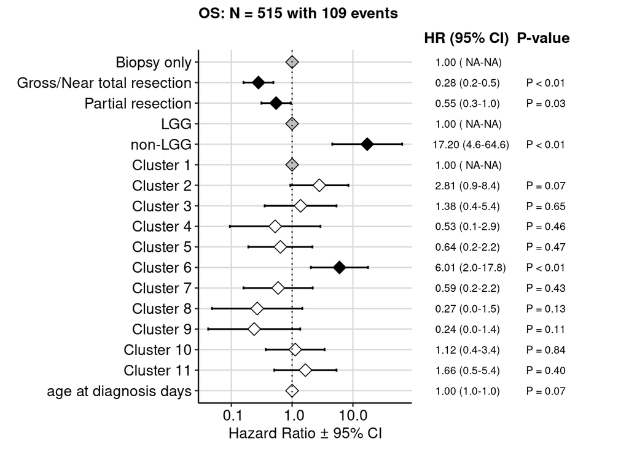

```r
add_model_os <- fit_save_model(metadata[!metadata$extent_of_tumor_resection %in% c("Not Reported", "Unavailable"),],
                              terms = "extent_of_tumor_resection+lgg_group+cluster+age_at_diagnosis_days",
                               file.path(results_dir, "cox_OS_additive_terms_resection_lgg_group_cluster.RDS"),
                               "multivariate",
                               years_col = "OS_years",
                               status_col = "OS_status")

forest_os <- plotForest(readRDS(file.path(results_dir, "cox_OS_additive_terms_resection_lgg_group_cluster.RDS")))
```

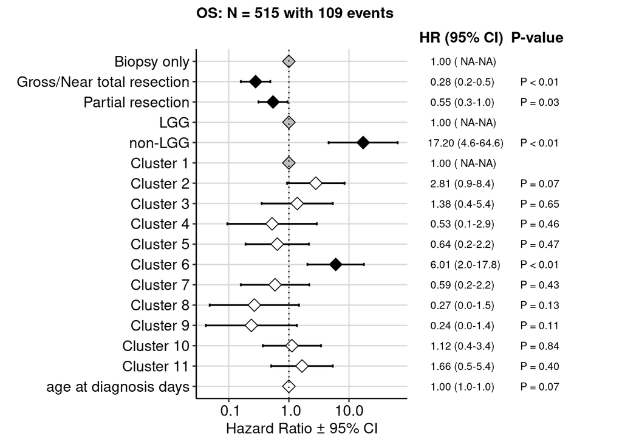

```r
forest_os
```

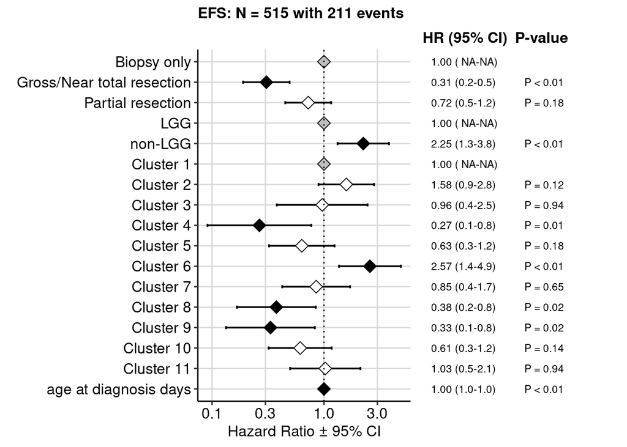

```r
ggsave(file.path(plot_dir, "forest_add_OS_resection_lgg_group_cluster_assignment.pdf"),
       forest_os,
       width = 10, height = 6, units = "in",
       device = "pdf")

add_model_efs <- fit_save_model(metadata[!metadata$extent_of_tumor_resection %in% c("Not Reported", "Unavailable"),],
                              terms = "extent_of_tumor_resection+lgg_group+cluster+age_at_diagnosis_days",
                               file.path(results_dir, "cox_EFS_additive_terms_resection_lgg_group_cluster.RDS"),
                               "multivariate",
                               years_col = "EFS_years",
                               status_col = "EFS_status")

forest_efs <- plotForest(readRDS(file.path(results_dir, "cox_EFS_additive_terms_resection_lgg_group_cluster.RDS")))
```

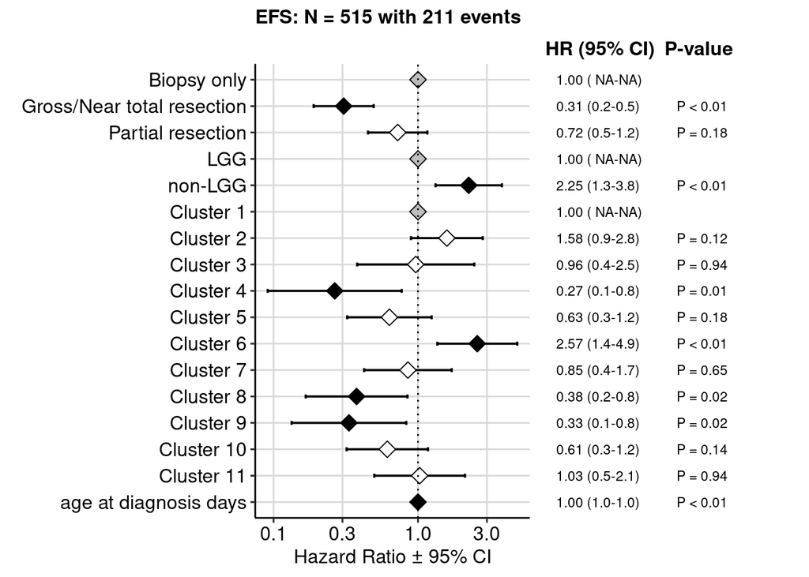

```r
forest_efs
```

```r
ggsave(file.path(plot_dir, "forest_add_EFS_resection_lgg_group_cluster_assignment.pdf"),
       forest_efs,
       width = 10, height = 6, units = "in",
       device = "pdf")
```

Subset `metadata` for LGG, and only include clusters with >= 10 samples

```r
lgg <- metadata %>%
  dplyr::filter(Histology == "Low-grade glioma") %>%
  dplyr::mutate(cluster = factor(cluster)) %>%
  dplyr::mutate(mol_sub_group = fct_relevel(mol_sub_group, c("Wildtype", "BRAF V600E", "BRAF fusion",
                                                                "Other alteration", "SEGA"
                                                                )))

retain_clusters_lgg <- lgg %>%
  count(cluster) %>%
  filter(n >= 10) %>%
  pull(cluster)

lgg <- lgg %>%
  filter(cluster %in% retain_clusters_lgg) %>%
    dplyr::mutate(cluster = factor(cluster))
```

Generate log rank OS and EFS models with cluster assignment as predictor

```r
# Generate kaplan meier survival models for OS and EFS, and save outputs
lgg_kap_os <- survival_analysis(
  metadata  = lgg,
  ind_var = "cluster",
  test = "kap.meier",
  metadata_sample_col = "Kids_First_Biospecimen_ID",
  days_col = "OS_days",
  status_col = "OS_status"
)
```

```
Testing model: survival::Surv(OS_days, OS_status) ~ cluster with kap.meier
```

```r
readr::write_rds(lgg_kap_os,
                 file.path(results_dir, "logrank_lgg_OS_cluster_assignment.RDS"))

lgg_kap_efs <- survival_analysis(
  metadata  = lgg,
  ind_var = "cluster",
  test = "kap.meier",
  metadata_sample_col = "Kids_First_Biospecimen_ID",
  days_col = "EFS_days",
  status_col = "EFS_status"
)
```

```
Testing model: survival::Surv(EFS_days, EFS_status) ~ cluster with kap.meier
```

```r
readr::write_rds(lgg_kap_efs,
                 file.path(results_dir, "logrank_lgg_EFS_cluster_assignment.RDS"))
```

Generate LGG KM plots

```r
km_lgg_os_plot <- plotKM(model = lgg_kap_os,
                    variable = "cluster",
                    combined = F,
                    title = "cluster",
                    palette = cluster_cols[names(cluster_cols) %in% retain_clusters_lgg])
ggsave(file.path(plot_dir, "km_lgg_OS_cluster_assignment.pdf"),
       km_lgg_os_plot,
       width = 10, height = 6, units = "in",
       device = "pdf")
km_lgg_efs_plot <- plotKM(model = lgg_kap_efs,
                    variable = "cluster",
                    combined = F,
                    title = "cluster",
                    palette = cluster_cols[names(cluster_cols) %in% retain_clusters_lgg])
ggsave(file.path(plot_dir, "km_lgg_EFS_cluster_assignment.pdf"),
       km_lgg_efs_plot,
       width = 10, height = 6, units = "in",
       device = "pdf")
```

Generate coxph models including covariates `extent_of_tumor_resection`, `mol_sub_group`, and `cluster`, and plot

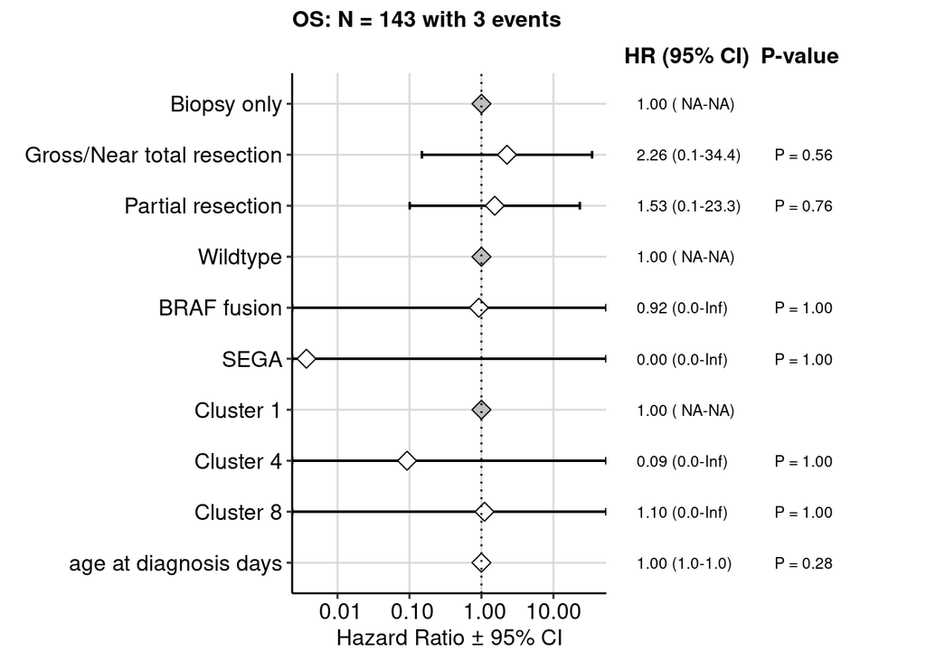

```r
add_model_lgg_os <- fit_save_model(lgg[!lgg$extent_of_tumor_resection %in% c("Not Reported", "Unavailable"),],
                              terms = "extent_of_tumor_resection+mol_sub_group+cluster+age_at_diagnosis_days",
                               file.path(results_dir, "cox_lgg_OS_additive_terms_resection_subtype_cluster.RDS"),
                               "multivariate",
                               years_col = "OS_years",
                               status_col = "OS_status")
forest_lgg_os <- plotForest(readRDS(file.path(results_dir, "cox_lgg_OS_additive_terms_resection_subtype_cluster.RDS")))
```

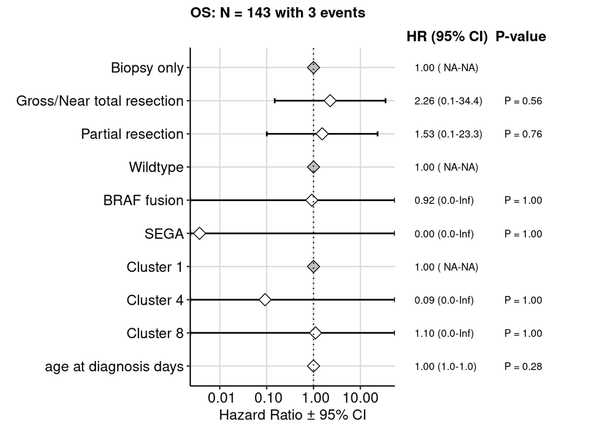

```r
forest_lgg_os
```

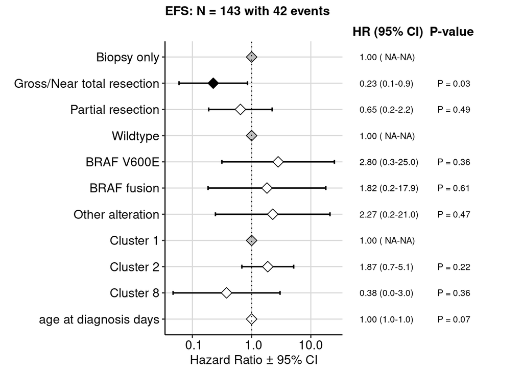

```r
ggsave(file.path(plot_dir, "forest_add_OS_LGG_resection_subtype_cluster_assignment.pdf"),
       forest_lgg_os,
       width = 10, height = 6, units = "in",
       device = "pdf")

# identify LGG clusters
lgg_clusters <- metadata %>%
  filter(lgg_group == "LGG") %>%
  mutate(cluster = as.integer(gsub("cluster", "", cluster))) %>%
  pull(cluster) %>%
  sort() %>%
  unique()
add_model_lgg_efs <- fit_save_model(lgg[!lgg$cluster %in% lgg_clusters & !lgg$extent_of_tumor_resection %in% c("Not Reported", "Unavailable"),],
                              terms = "extent_of_tumor_resection+mol_sub_group+cluster+age_at_diagnosis_days",
                               file.path(results_dir, "cox_lgg_EFS_additive_terms_resection_subtype_cluster.RDS"),
                               "multivariate",
                               years_col = "EFS_years",
                               status_col = "EFS_status")
forest_lgg_efs <- plotForest(readRDS(file.path(results_dir, "cox_lgg_EFS_additive_terms_resection_subtype_cluster.RDS")))
```

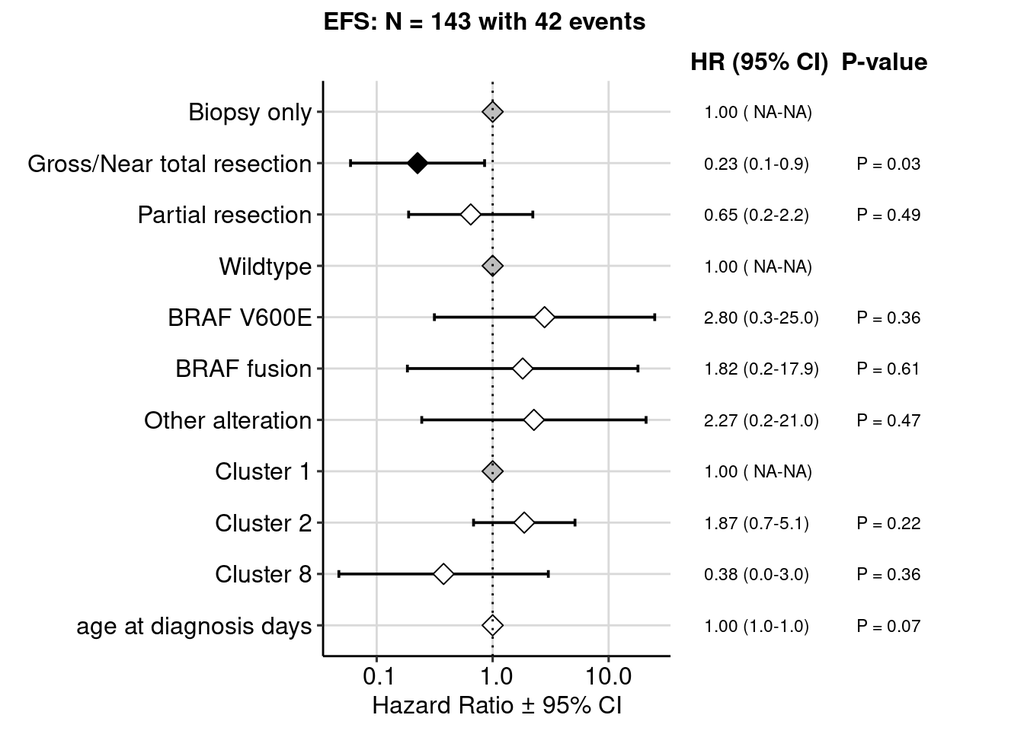

```r
forest_lgg_efs
```

```r
ggsave(file.path(plot_dir, "forest_add_EFS_LGG_resection_subtype_cluster_assignment.pdf"),
       forest_lgg_efs,
       width = 10, height = 6, units = "in",
       device = "pdf")
```

Subset `metadata` for HGG and retain cluster with n >= 10

```r
hgg <- metadata %>%
  dplyr::filter(Histology %in% c("Other high-grade glioma", "DIPG or DMG")) %>%
  dplyr::mutate(cluster = factor(cluster)) %>%
  dplyr::mutate(mol_sub_group = fct_relevel(mol_sub_group, c("HGG, H3 wildtype", "HGG, H3 wildtype, TP53",
                                                             "DMG, H3 K28", "DMG, H3 K28, TP53",
                                                                "DHG, H3 G35", "DHG, H3 G35, TP53",
                                                                "HGG, IDH, TP53", "HGG, PXA", "HGG, PXA, TP53",
                                                                "IHG, ALK-altered", "IHG, NTRK-altered",
                                                                "IHG, ROS1-altered"
                                                                )))
retain_clusters_hgg <- hgg %>%
  count(cluster) %>%
  filter(n >= 10) %>%
  pull(cluster)

hgg <- hgg %>%
  filter(cluster %in% retain_clusters_hgg) %>%
  dplyr::mutate(cluster = factor(cluster))
```

Generate HGG OS and EFS log rank models with cluster as predictor

```r
# Generate kaplan meier survival models for OS and EFS, and save outputs
hgg_kap_os <- survival_analysis(
  metadata  = hgg,
  ind_var = "cluster",
  test = "kap.meier",
  metadata_sample_col = "Kids_First_Biospecimen_ID",
  days_col = "OS_days",
  status_col = "OS_status"
)
```

```
Testing model: survival::Surv(OS_days, OS_status) ~ cluster with kap.meier
```

```r
readr::write_rds(hgg_kap_os,
                 file.path(results_dir, "logrank_hgg_OS_cluster_assignment.RDS"))

hgg_kap_efs <- survival_analysis(
  metadata  = hgg,
  ind_var = "cluster",
  test = "kap.meier",
  metadata_sample_col = "Kids_First_Biospecimen_ID",
  days_col = "EFS_days",
  status_col = "EFS_status"
)
```

```
Testing model: survival::Surv(EFS_days, EFS_status) ~ cluster with kap.meier
```

```r
readr::write_rds(hgg_kap_efs,
                 file.path(results_dir, "logrank_hgg_EFS_cluster_assignment.RDS"))
```

Generate HGG KM plots

```r
km_hgg_os_plot <- plotKM(model = hgg_kap_os,
                    variable = "cluster",
                    combined = F,
                    title = "cluster",
                    palette = cluster_cols[names(cluster_cols) %in% retain_clusters_hgg])
ggsave(file.path(plot_dir, "km_hgg_OS_cluster_assignment.pdf"),
       km_hgg_os_plot,
       width = 10, height = 6, units = "in",
       device = "pdf")
km_hgg_efs_plot <- plotKM(model = hgg_kap_efs,
                    variable = "cluster",
                    combined = F,
                    title = "cluster",
                    palette = cluster_cols[names(cluster_cols) %in% retain_clusters_hgg])
ggsave(file.path(plot_dir, "km_hgg_EFS_cluster_assignment.pdf"),
       km_hgg_efs_plot,
       width = 10, height = 6, units = "in",
       device = "pdf")
```

Generate coxph models for HGG including covariates `mol_sub_group` and `cluster`, and plot

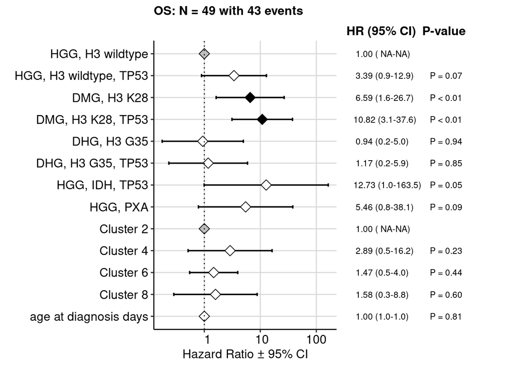

```r
add_model_hgg_os <- fit_save_model(hgg,
                              terms = "mol_sub_group+cluster+age_at_diagnosis_days",
                               file.path(results_dir, "cox_hgg_OS_additive_terms_subtype_cluster.RDS"),
                               "multivariate",
                               years_col = "OS_years",
                               status_col = "OS_status")
forest_hgg_os <- plotForest(readRDS(file.path(results_dir, "cox_hgg_OS_additive_terms_subtype_cluster.RDS")))
```

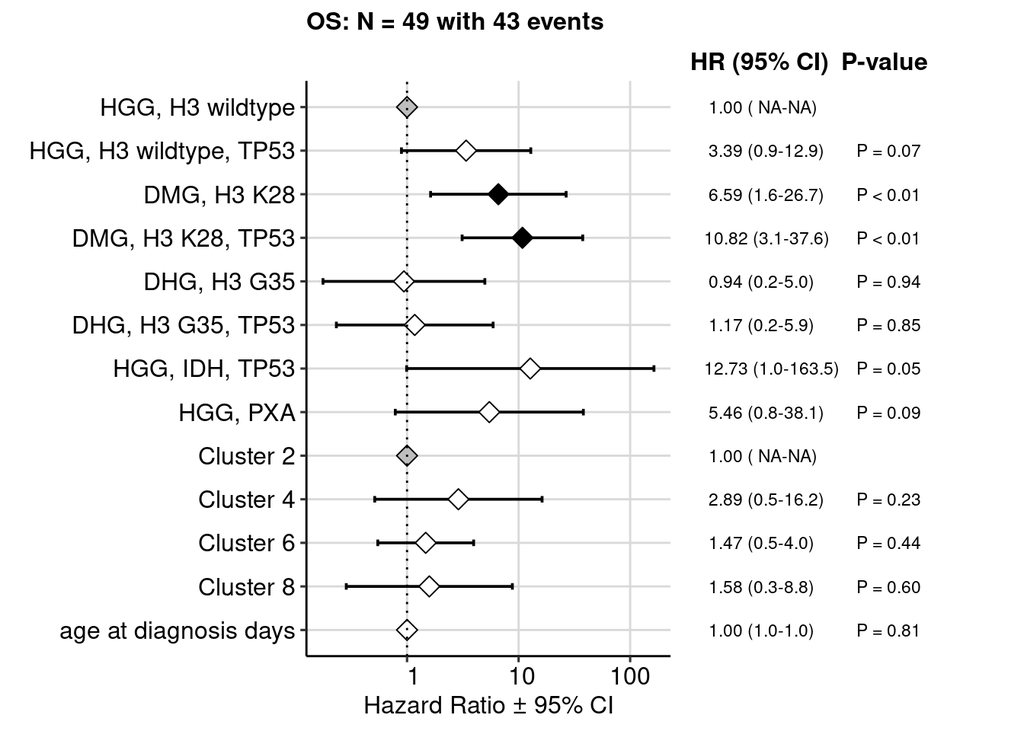

```r
forest_hgg_os
```

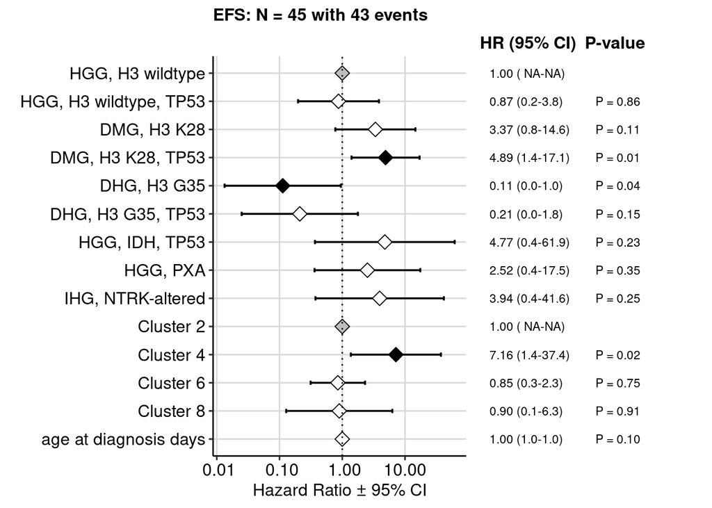

```r
ggsave(file.path(plot_dir, "forest_add_OS_HGG_subtype_cluster_assignment.pdf"),
       forest_hgg_os,
       width = 10, height = 6, units = "in",
       device = "pdf")

add_model_hgg_efs <- fit_save_model(hgg,
                              terms = "mol_sub_group+cluster+age_at_diagnosis_days",
                               file.path(results_dir, "cox_hgg_EFS_additive_terms_subtype_cluster.RDS"),
                               "multivariate",
                               years_col = "EFS_years",
                               status_col = "EFS_status")

forest_hgg_efs <- plotForest(readRDS(file.path(results_dir, "cox_hgg_EFS_additive_terms_subtype_cluster.RDS")))
```

```r
ggsave(file.path(plot_dir, "forest_add_EFS_HGG_subtype_cluster_assignment.pdf"),
       forest_hgg_efs,
       width = 10, height = 6, units = "in",
       device = "pdf")
```